# COVID-19 Vaccine Equity Analysis

C. Scott Smith, PhD AICP

4/20/2021

# 1 Background

## 1.1 COVID-19 Burden in Chicago

## 1.2 COVID-19 Vaccination Disparities

| Dominant Group | First Doses | Pop 18+ | First Dose Rate (%) |
| --- | --- | --- | --- |
| ASIAN | 22,305 | 46,368 | 48.1 |
| BLACK | 231,722 | 608,511 | 38.1 |
| LATINX | 253,029 | 484,310 | 52.2 |
| WHITE | 579,840 | 1,046,198 | 55.4 |

| Avg Poverty Rate | First Doses | Pop 18+ | First Dose Rate (%) |
| --- | --- | --- | --- |
| 6.84 | 181,363 | 339,176 | 53.5 |
| 10.10 | 260,218 | 467,498 | 55.7 |
| 17.10 | 323,665 | 590,881 | 54.8 |
| 23.60 | 188,343 | 439,189 | 42.9 |
| 33.30 | 133,307 | 348,643 | 38.2 |

| PCP Neighborhood | First Doses | Pop 18+ | First Dose Rate (%) |
| --- | --- | --- | --- |
| NO | 841,433 | 1,632,972 | 51.5 |
| YES | 245,463 | 552,415 | 44.4 |

## 1.3 Research Questions

This research aims to respond to the following research questions:

1. Are there disparities in vaccination rates across Chicago communities with different race, ethnic, socioeconomic and COVID-19 burden characteristics?
2. If such disparities do exist, to what extent has Chicago’s Protect Chicago Plus program mitigated them?

# 2 Methodology

We employ a series of chi-square analyses to evaluate disparities in vaccination rates across communities categorized by dominant race and ethnic group, poverty status and relative COVID-19 burden. Interrupted time series analysis (ITS) is then used to evaluate the impact of the city’s Protect Chicago Plus program on different measures of vaccination coverage and disparity, pre- and post-intervention.

## 2.1 Data

To carry out the above analyses, we rely on publicly available data including the following:

1. socioeconomic data including race, ethnicity, socioeconomic status and age composition from the US Census Bureau’s American Community Survey (ACS), 2015 to 2019 5-year estimates;
2. cumulative daily first vaccination counts from the City of Chicago’s data portal; and
3. information from the City of Chicago and related media reports concerning the geographic scope and implementation of the city’s Protect Chicago Plus program.

## 2.2 Analysis

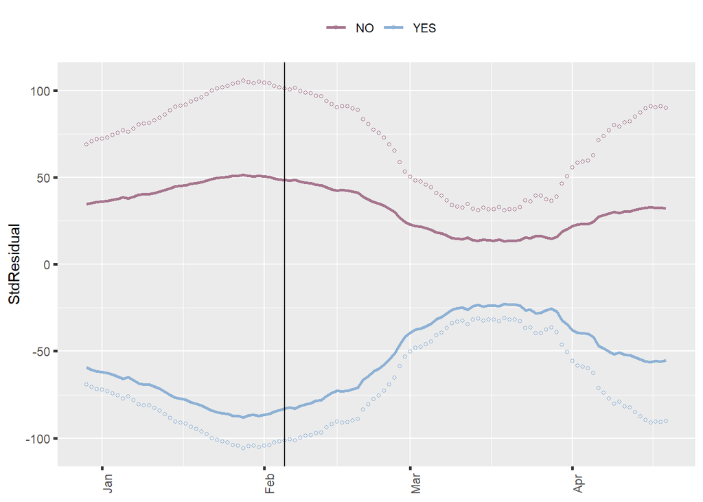

```
## # A tibble: 2 x 2
##       D `n()`
## * <dbl> <int>
## 1     0  3016
## 2     1  4292
```

## 2.3 Resources

https://ds4ps.org/pe4ps-textbook/docs/p-020-time-series.html https://ds4ps.org/pe4ps-textbook/docs/p-020-time-series.html https://online.stat.psu.edu/stat462/node/188/ https://www-sciencedirect-com.ezproxy.depaul.edu/science/article/pii/S0277953602005026 https://worldwidescience.org/topicpages/v/vaccination+odds+ratio.html https://www.quora.com/What-is-an-equivalent-of-the-chi-square-test-for-time-series-data